# Pitcher card

# Alex Lange

RHP · KC

2026 · 59 G (0 GS) · 1,135 pitches · Mar 27 – Sep 26, 2026

Independent portfolio sample by Devin Jenkinson, not affiliated with any club. Every number is computed from public Statcast data.

Three big takeaways

1Attack

Lean on the changeup with two strikes. It misses the most bats.

28% of two-strike pitches · 29% whiffs/swing (55 swings)

It grades 105 Stuff+. Next best two-strike miss rate: the slider at 25%.

2Avoid

Limit the 4-seam fastball. It is his most damaging pitch.

xRV/100 -0.84 shrunk (raw -2.47) · .514 xwOBAcon · 116 pitches

When behind in the count he throws it 10% of the time; the slider grades +0.06 there instead.

3Watch

After the changeup, hitters chase the slider most.

34% chased on 202 out-of-zone pitches

Fastball height splits are too thin to call (26 swings up, 51 down).

Charts

### Movement

The SL finishes 17 in from his SI, with 15 in more glove-side run.

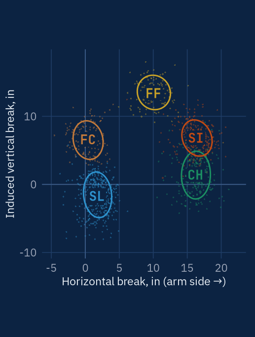

n = 1,135 pitches. Ellipses hold about 68% of each type; codes sit at the averages.

### Location by count

He throws 57% of pitches in the zone when behind and 30% when ahead.

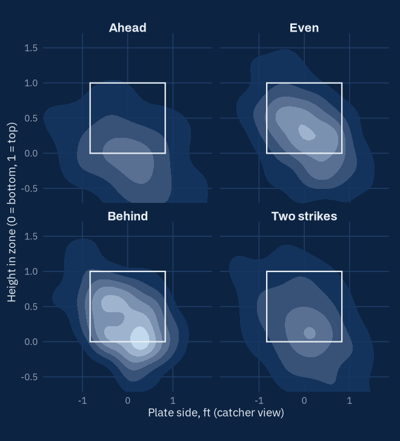

n = 1,135. Ahead 138 · even 410 · behind 250 · two strikes 337 pitches. Box = rule-book zone.

### Put-away

The SL is 41% of two-strike pitches vs 31% overall.

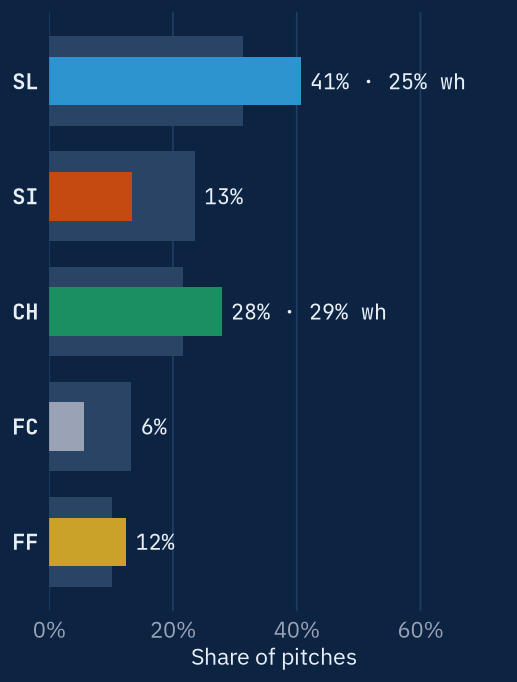

Two-strike n: SL 137, CH 94, SI 45, FF 42, FC 19. Grey bars = overall usage; wh = whiffs per swing (shown with 50+ swings).

### Arsenal

[output not shown]

IVB / HB in inches (HB + = arm side). VAA in degrees at the front of the plate. xRV/100 = expected run value per 100 pitches, pitcher’s view, shrunk with a 250-pitch prior. Stuff+ = this project’s shape-only model (100 = MLB average, 10 = 1 SD).

### Vs. batter hand

| Pitch | LHH # | Use | Whiff | xwOBAcon | RHH # | Use | Whiff | xwOBAcon |
| --- | --- | --- | --- | --- | --- | --- | --- | --- |
| SL | 163 | 25% | 29% | .346 | 193 | 40% | 46% | .247 |
| SI | 92 | 14% | – | .548 | 175 | 36% | 22% | .358 |
| CH | 219 | 34% | 30% | .260 | 26 | 5% | – | .228 |
| FC | 107 | 16% | – | .454 | 44 | 9% | – | .417 |
| FF | 71 | 11% | – | .520 | 45 | 9% | – | .336 |

Use = share of pitches to that side. Whiff = whiffs per swing, shown with 50+ swings.